# Topology of a reservoir network with HydroSHEDS

JM Delgado

2020-06-04

# Global datasets of rivers and reservoirs

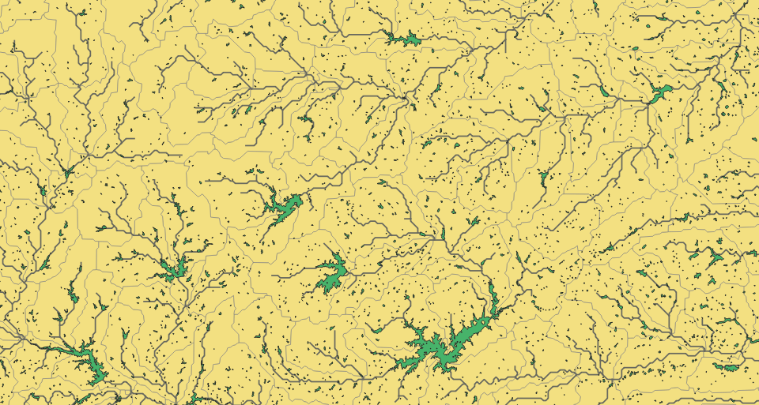

Topological complexity

## Rivers

We use HydroSHEDS as a consistent global river dataset. The resolution is about 90 m around the equator (3 arc-seconds).

> Lehner, B., Verdin, K., Jarvis, A. (2008): New global hydrography derived from spaceborne elevation data. Eos, Transactions, AGU, 89(10): 93-94.

### For example in Ceará:

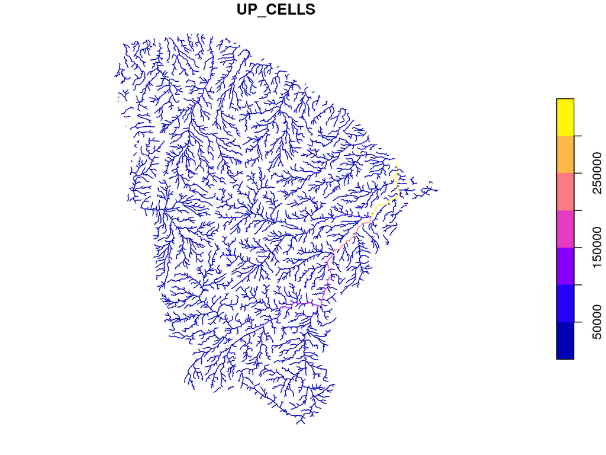

```r
plot(river_geometry["UP_CELLS"])
```

```r
# ggplot(river_geometry) + geom_sf(aes(color=UP_CELLS))
```

### Disjoint components of the graph

Since the river network dataset of HydroSHEDS has valid topology, we can operate on it with package `igraph`, using graph theory. We can for example obtain **all disjoint components of the graph**:

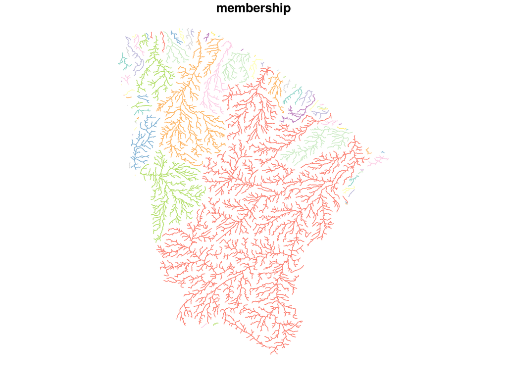

```r
riv_split = split_river_network(river_geometry)
plot(riv_split["membership"])
```

```r
split_river_network
```

```
#> function (riv)
#> {
#>     touching_list = st_touches(riv)
#>     adjacency_list = st_touches(riv)
#>     g = graph.adjlist(adjacency_list)
#>     c = components(g)
#>     riv_n = mutate(riv, membership = as.factor(c$membership)) %>%
#>         arrange()
#>     return(riv_n)
#> }
#> <bytecode: 0x55ed719fb668>
#> <environment: namespace:a5udes>
```

Selecting a river system by a reach id, eg in the Jaguaribe river basin:

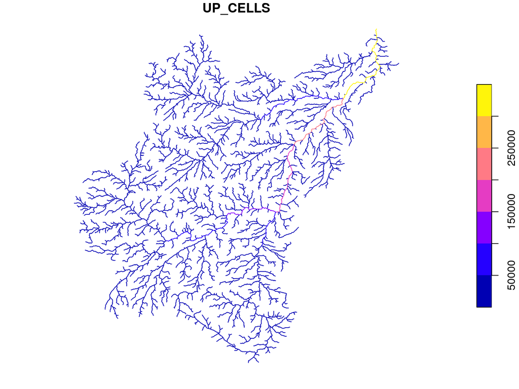

```r
reach_id=140877
riv_jagua = select_disjoint_river(reach_id,riv_split)
plot(riv_jagua["UP_CELLS"])
```

## Reservoirs

We use the JRC global surface water dataset.

> Jean-Francois Pekel, Andrew Cottam, Noel Gorelick, Alan S. Belward, High-resolution mapping of global surface water and its long-term changes. Nature 540, 418-422 (2016). (doi:10.1038/nature20584)

Resolution is 30 m. We run

- `allocate_reservoir_to_river(riv_jagua)`, with e.g. `riv_jagua` obtained in the previous step;
- `route_reservoir_along_river(reservoir_geometry_subset)`; and
- `route_reservoir_to_river(reservoir_geometry_subset)`

in advance in order to create a graph. Then we can obtain any subgraph of choice.

```r
head(reservoir_graph)
```

```
#> 6 x 22912 sparse Matrix of class "dgCMatrix"
#>    [[ suppressing 31 column names '3', '4', '5' ... ]]
#>
#> 3 . . . . . . . . . . . . . . . . . . . . . . . . . . . . . . . ......
#> 4 . . . . . . . . . . . . . . . . . . . . . . . . . . . . . . . ......
#> 5 1 . . . . . . . . . . . . . . . . . . . . . . . . . . . . . . ......
#> 6 . . 1 . . . . . . . . . . . . . . . . . . . . . . . . . . . . ......
#> 7 . . 1 . . . . . . . . . . . . . . . . . . . . . . . . . . . . ......
#> 8 . . . . . . . . . . . . . . . . . . . . . . . . . . . . . . . ......
#>
#>  .....suppressing 22881 columns in show(); maybe adjust 'options(max.print= *, width = *)'
#>  ..............................
```

### Small example with reservoir 34560

*Example 1:* Identify adjacent reservoirs upstream of 34560:

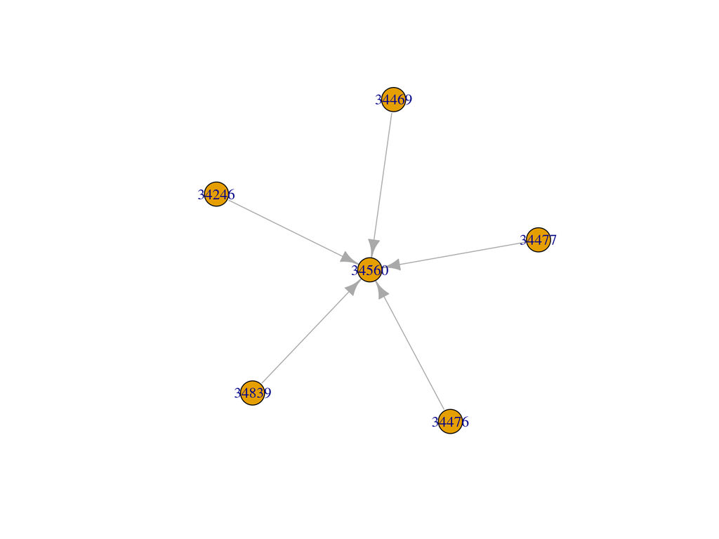

```r
id='34560'
adj_subgraph=make_ego_graph(reservoir_graph, order = 1, nodes = id, mode = "in", mindist = 0)
plot(adj_subgraph[[1]])
```

…and plot them on a georreferenced map:

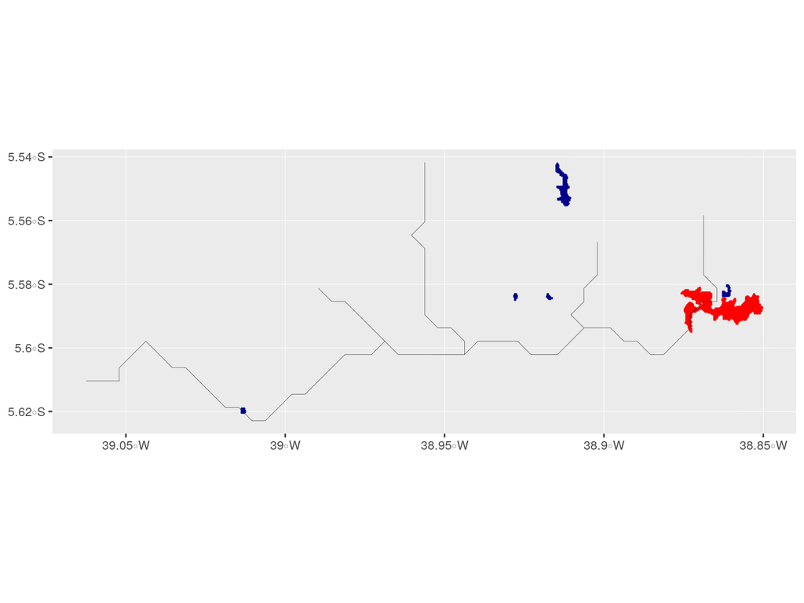

```r
adj=neighbors(reservoir_graph,id,"in")
res_adj=filter(reservoir_geometry,id_jrc %in% adj$name)
res_id=filter(reservoir_geometry,id_jrc %in% id)



ind=st_combine(res_adj) %>% st_convex_hull %>% st_intersects(river_geometry)
river_subset=river_geometry[ind[[1]],]

ggplot() +
  geom_sf(data=res_adj,color='darkblue',fill='darkblue') +
  geom_sf(data=res_id,color='red',fill='red') +
  geom_sf(data=river_subset,color='black',size=0.1)
```

*Example 2:* Identify all reservoirs upstream of 34560:

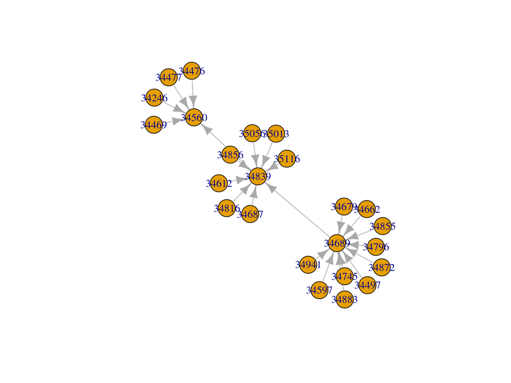

```r
sub=all_simple_paths(reservoir_graph,from=id,mode='in') %>%
  unlist %>%
  unique

Vsubgraph = induced_subgraph(reservoir_graph, sub ,impl='auto')

plot(Vsubgraph)
```

…and plot them on a georreferenced map:

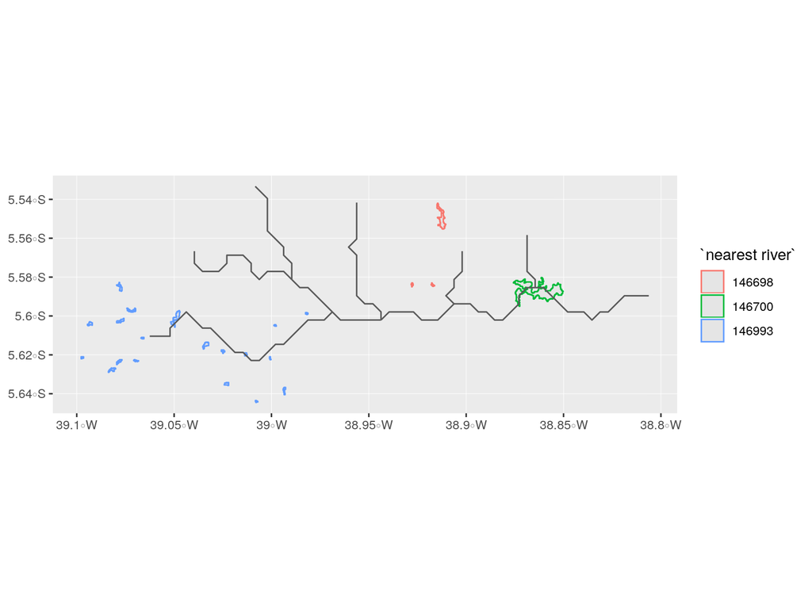

```r
vertices = V(Vsubgraph)

res_subset = filter(reservoir_geometry,reservoir_geometry$id_jrc %in% vertices$name)

reach_id = filter(res_subset,`id_jrc`==id) %>%
  pull(`nearest river`)
riv_upstr=river_upstream(reach_id,river_geometry,river_graph)

res_subset %>%
  mutate(`nearest river`=as.factor(`nearest river`)) %>%
  ggplot(.) +
    geom_sf(aes(color=`nearest river`)) +
    geom_sf(data=riv_upstr)
```